# EDLD 652 Lab 3

Ksenia Gordeeva, Rebeccca Gordon, Amy Warnock

2/7/2022

### 1. Visualize the total production of honey across years by state. Use color to highlight the west coast (Washington, Oregon, and California) with a different color used for each west coast state.

```r
honey <- import(here("data", "honeyproduction.csv"), setclass = "tbl_df")
regions <- import(here("data", "us_census_bureau_regions_and_divisions.csv"), setclass = "tbl_df") %>%
  rename(state = `State Code`, `state_complete` = State) %>%
  rename_with(tolower)
honey_full <- left_join(honey, regions, by = "state")

#Change scale of total production
honey_full$totalprod  <- honey_full$totalprod/1000000

total_prod <- honey_full %>%
    select(state_complete, totalprod, year) %>%
    #group_by(state_complete) %>%
    mutate(state_complete = as.factor(state_complete))
str(total_prod)
```

```
## tibble [626 × 3] (S3: tbl_df/tbl/data.frame)
##  $ state_complete: Factor w/ 44 levels "Alabama","Arizona",..: 1 2 3 4 5 6 7 8 9 10 ...
##  $ totalprod     : num [1:626] 1.14 3.3 3.44 37.35 1.94 ...
##  $ year          : int [1:626] 1998 1998 1998 1998 1998 1998 1998 1998 1998 1998 ...
```

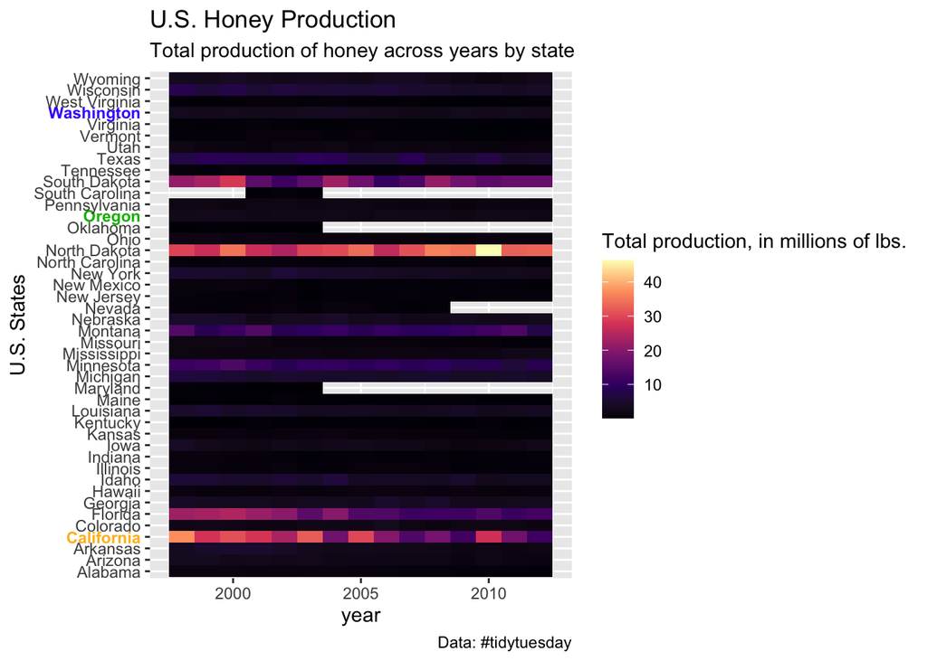

```r
states <- unique(total_prod$state_complete)
states <- sort(states)
label_color <- ifelse(states == "Oregon", "#03b800",
                      ifelse(states == "Washington", "#4714ff",
                             ifelse(states == "California", "#ffbc1f",
                "gray30")))

label_face <- ifelse(states == "Oregon" | states == "Washington" | states == "California",
                "bold",
                "plain")


ggplot(total_prod, aes(year, state_complete)) +
  geom_tile(aes(fill = totalprod)) +
  labs(y = "U.S. States",
       fill = "Total production, in millions of lbs.",
       title = "U.S. Honey Production",
         subtitle = "Total production of honey across years by state",
         caption = "Data: #tidytuesday") +
  #gghighlight(state_complete %in% c("California", "Oregon", "Washington")) +
  #scale_y_discrete(limits = rev(levels(total_prod$state_complete))) +
  theme(axis.text.y = element_text(color = label_color,face = label_face))+
   scale_fill_viridis_c(option = "magma")
```

I tried using the heatmap next.

```r
str(honey_full)
```

```
## tibble [626 × 11] (S3: tbl_df/tbl/data.frame)
##  $ state         : chr [1:626] "AL" "AZ" "AR" "CA" ...
##  $ numcol        : num [1:626] 16000 55000 53000 450000 27000 230000 75000 8000 120000 9000 ...
##  $ yieldpercol   : int [1:626] 71 60 65 83 72 98 56 118 50 71 ...
##  $ totalprod     : num [1:626] 1.14 3.3 3.44 37.35 1.94 ...
##  $ stocks        : num [1:626] 159000 1485000 1688000 12326000 1594000 ...
##  $ priceperlb    : num [1:626] 0.72 0.64 0.59 0.62 0.7 0.64 0.69 0.77 0.65 1.19 ...
##  $ prodvalue     : num [1:626] 818000 2112000 2033000 23157000 1361000 ...
##  $ year          : int [1:626] 1998 1998 1998 1998 1998 1998 1998 1998 1998 1998 ...
##  $ state_complete: chr [1:626] "Alabama" "Arizona" "Arkansas" "California" ...
##  $ region        : chr [1:626] "South" "West" "South" "West" ...
##  $ division      : chr [1:626] "East South Central" "Mountain" "West South Central" "Pacific" ...
```

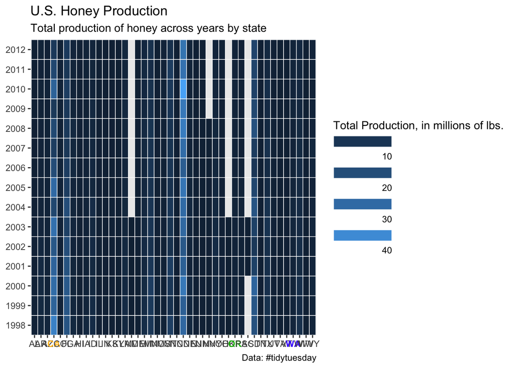

```r
ggplot(honey_full, aes(state, year, fill = totalprod))+
    geom_tile(color = "white", size = 0.25) +
    labs(title = "U.S. Honey Production",
         subtitle = "Total production of honey across years by state",
         caption = "Data: #tidytuesday") +
    scale_y_continuous(breaks = seq(1998, 2012, 1), expand = c(0, 0))+
  #scale_fill_brewer(palette = "YlOrRd") +
    #scale_fill_brewer(palette = "YlOrRd", direction = -1,
                      #labels = c("-21.1%", "8.7", "3.2", "19.3", "134"))+
    guides(fill = guide_legend(title = "Total Production, in millions of lbs.",
                               label.position = "bottom",
                               label.hjust = 1,
                               keywidth = 4,
                               keyheight = .8))+
    theme(panel.grid.major = element_blank(),
          axis.title = element_blank(),
          axis.text.x = element_text(color = label_color,face = label_face))
```

Another way to vizualize the change over time with highlighting the western states, is to have a line plot, with all the states besides Western ones being in the background. Below are versions with 3 Western states together, and with each of them faceted separately.

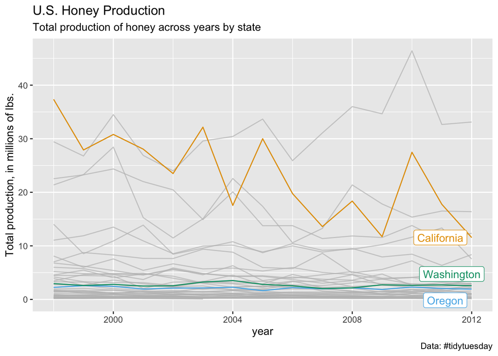

```r
ggplot(total_prod, aes(year, totalprod, color = state_complete)) +
    geom_line()+
 gghighlight(state_complete %in% c("California", "Oregon", "Washington")) +
  scale_color_OkabeIto() +
    labs(y = "Total production, in millions of lbs.",
         title = "U.S. Honey Production",
         subtitle = "Total production of honey across years by state",
         caption = "Data: #tidytuesday")
```

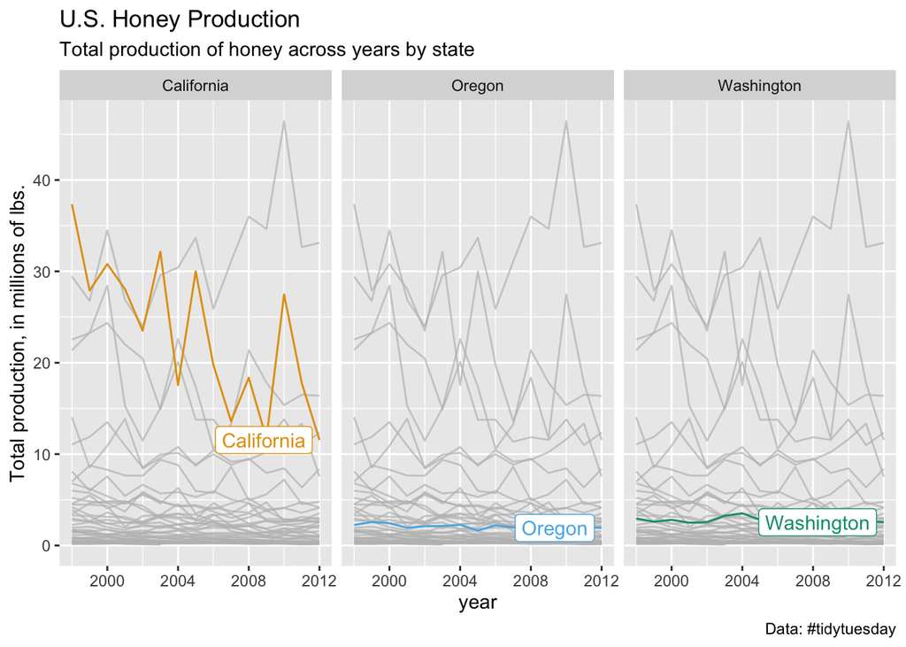

```r
ggplot(total_prod, aes(year, totalprod, color = state_complete)) +
    geom_line()+
  facet_wrap(~state_complete) +
 gghighlight(state_complete %in% c("California", "Oregon", "Washington")) +
  scale_color_OkabeIto() +
  labs(y = "Total production, in millions of lbs.",
         title = "U.S. Honey Production",
         subtitle = "Total production of honey across years by state",
         caption = "Data: #tidytuesday")
```

I also made a line plot for each state. Besides highlighting the line for each Western state by different color, I tried using the Label of the state printed differently as well. However, ggplot was not accepting a vector of colors for ‘element_text()’, and none of the troubleshooting helped.

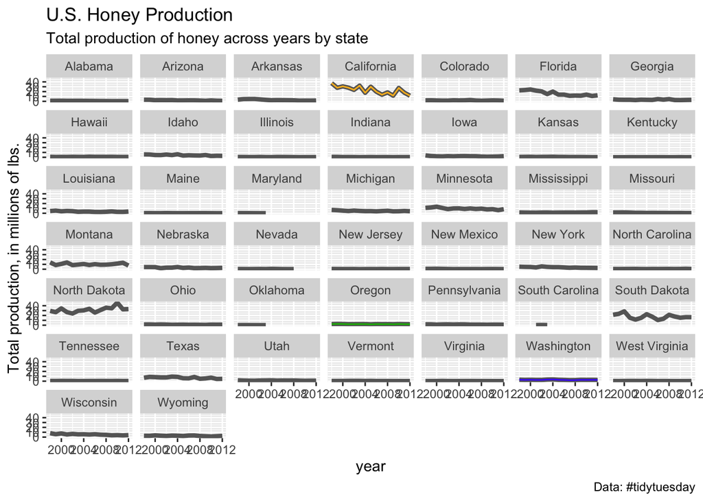

```r
states <- unique(total_prod$state_complete)
label_color <- ifelse(states == "Oregon", "#03b800",
                      ifelse(states == "Washington", "#4714ff",
                             ifelse(states == "California", "#ffbc1f",
                "gray30")))

label_face <- ifelse(states == "Oregon" | states == "Washington" | states == "California",
                "bold",
                "plain")

total_prod %>%
    spread(state_complete, totalprod) %>%
    gather(state_complete, totalprod, -year) %>%
    ggplot(aes(year,  totalprod)) +
    geom_line(colour = "grey40", size = 1.5) +
    geom_line(data = filter(total_prod, str_detect(state_complete, "California")),
             color = "#ffbc1f") +
    geom_line(data = filter(total_prod, str_detect(state_complete, "Oregon")),
             color = "#03b800") +
    geom_line(data = filter(total_prod, str_detect(state_complete, "Washington")),
             color = "#4714ff") +
    facet_wrap(~state_complete) +
  theme(strip.text = element_text(color = label_color, face = label_face)) +
    labs(y = "Total production, in millions of lbs.",
         title = "U.S. Honey Production",
         subtitle = "Total production of honey across years by state",
         caption = "Data: #tidytuesday")
```

I have also tried creating the dumbbell plot to show the difference between 1998 and 2012 in honey production. That plot is not ideal, since it only shows the change between the initial and final points, without reflecting any fluctuations in between.

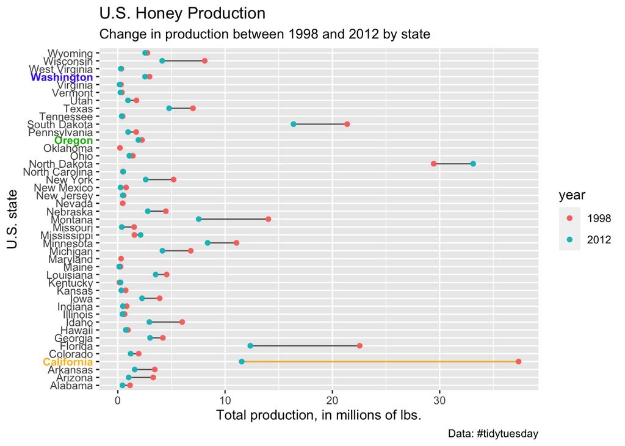

```r
dumbbell <- total_prod %>%
  mutate(year = as.character(year),
         state_complete = as.factor(state_complete))

#dumbbell$state_complete <- factor(dumbbell$state_complete, levels = rev(levels(dumbbell$state_complete)))

dumbbell <- dumbbell %>%
  filter(year %in% c("1998", "2012"))




ggplot(dumbbell, aes(totalprod, state_complete)) +
  geom_line(aes(group = state_complete), color = "gray40") +
  geom_line(data = filter(dumbbell, str_detect(state_complete, "California")),
             color = "#ffbc1f") +
  geom_line(data = filter(dumbbell, str_detect(state_complete, "Oregon")),
             color = "#015200") +
  geom_line(data = filter(dumbbell, str_detect(state_complete, "Washington")),
             color = "#2600ad") +
  geom_point(aes(color = year)) +
  labs(x = "Total production, in millions of lbs.",
       y = "U.S. state",
       title = "U.S. Honey Production",
       subtitle = "Change in production between 1998 and 2012 by state",
       caption = "Data: #tidytuesday") +
  theme(axis.text.y = element_text(color = label_color, face = label_face))
```

```r
str(dumbbell)
```

```
## tibble [83 × 3] (S3: tbl_df/tbl/data.frame)
##  $ state_complete: Factor w/ 44 levels "Alabama","Arizona",..: 1 2 3 4 5 6 7 8 9 10 ...
##  $ totalprod     : num [1:83] 1.14 3.3 3.44 37.35 1.94 ...
##  $ year          : chr [1:83] "1998" "1998" "1998" "1998" ...
```

```r
#install.packages("gganimate")
library(gganimate)

#Add total production data to a map dataframe for plotting
production_map <- map_data("state")

honey_full$state_complete <- honey_full$state_complete %>%
  tolower()
production_map2 <- production_map %>%
  full_join(honey_full, by = c("region" = "state_complete"))
str(production_map2)
```

```
## 'data.frame':    212084 obs. of  16 variables:
##  $ long       : num  -87.5 -87.5 -87.5 -87.5 -87.5 ...
##  $ lat        : num  30.4 30.4 30.4 30.4 30.4 ...
##  $ group      : num  1 1 1 1 1 1 1 1 1 1 ...
##  $ order      : int  1 1 1 1 1 1 1 1 1 1 ...
##  $ region     : chr  "alabama" "alabama" "alabama" "alabama" ...
##  $ subregion  : chr  NA NA NA NA ...
##  $ state      : chr  "AL" "AL" "AL" "AL" ...
##  $ numcol     : num  16000 17000 16000 14000 12000 13000 12000 13000 11000 11000 ...
##  $ yieldpercol: int  71 68 78 73 86 82 87 66 72 56 ...
##  $ totalprod  : num  1.14 1.16 1.25 1.02 1.03 ...
##  $ stocks     : num  159000 185000 187000 235000 103000 43000 282000 266000 230000 209000 ...
##  $ priceperlb : num  0.72 0.56 0.59 0.72 1.18 1.24 1.41 1.02 1.21 1.49 ...
##  $ prodvalue  : num  818000 647000 736000 736000 1218000 ...
##  $ year       : int  1998 1999 2000 2001 2002 2003 2004 2005 2006 2007 ...
##  $ region.y   : chr  "South" "South" "South" "South" ...
##  $ division   : chr  "East South Central" "East South Central" "East South Central" "East South Central" ...
```

```r
str(honey_full)
```

```
## tibble [626 × 11] (S3: tbl_df/tbl/data.frame)
##  $ state         : chr [1:626] "AL" "AZ" "AR" "CA" ...
##  $ numcol        : num [1:626] 16000 55000 53000 450000 27000 230000 75000 8000 120000 9000 ...
##  $ yieldpercol   : int [1:626] 71 60 65 83 72 98 56 118 50 71 ...
##  $ totalprod     : num [1:626] 1.14 3.3 3.44 37.35 1.94 ...
##  $ stocks        : num [1:626] 159000 1485000 1688000 12326000 1594000 ...
##  $ priceperlb    : num [1:626] 0.72 0.64 0.59 0.62 0.7 0.64 0.69 0.77 0.65 1.19 ...
##  $ prodvalue     : num [1:626] 818000 2112000 2033000 23157000 1361000 ...
##  $ year          : int [1:626] 1998 1998 1998 1998 1998 1998 1998 1998 1998 1998 ...
##  $ state_complete: chr [1:626] "alabama" "arizona" "arkansas" "california" ...
##  $ region        : chr [1:626] "South" "West" "South" "West" ...
##  $ division      : chr [1:626] "East South Central" "Mountain" "West South Central" "Pacific" ...
```

```r
production_map2 <- production_map2 %>%
  mutate(year = as.factor(year))

#Create US map of honey production by stat
ggplot(production_map2, aes(long, lat)) +
  geom_polygon(aes(group = group,
                   fill = totalprod)) +
                   #frame = year)) +
  scale_fill_distiller(palette = "Spectral", labels = scales::comma) +
  coord_map('mercator') +
  theme_void() +
  theme(legend.position="bottom", legend.box="horizontal",
        legend.key.width=grid::unit(.1,'npc')) +
  guides(fill = guide_colourbar(title = "Honey Production (lbs)",
                                title.position="top",
                                title.hjust = 0.5))  +
  labs(title = 'Year: {frame_time}') +
  transition_time(year) +
  ease_aes('linear')
```

[output not shown]

```r
#Create dynamic ggplot map of production over time
#animate(h_map, "Plots/yearly_honey_production.gif", interval = 1) + transition_manual(year)
```